# Machine Learning Final Project

Joshua Parsell

March 3, 2022

# Introduction

The dataset provided at http://web.archive.org/web/20161224072740/http:/groupware.les.inf.puc-rio.br/har contains a large amount of orientation and acceleration data from four different sensors used to track subjects’ movements during a specific exercise. Under controlled guidance of an expert, the subjects performed the same exercise correctly (Classe A) and with four common types of mistakes (Classe B, C, D, and E). The goal of the project is to use the sensor data to build a model that can predict how the exercise was performed.

## Download Data

The data for this project come from this source: http://web.archive.org/web/20161224072740/http:/groupware.les.inf.puc-rio.br/har. The data for this project come from this source: http://groupware.les.inf.puc-rio.br/har. If you use the document you create for this class for any purpose please cite them as they have been very generous in allowing their data to be used for this kind of assignment.

## Load and Clean Data

First load the data which has been downloaded as two CSV files. Fix column name misspellings and coerce columns to numeric where appropriate. If more than 90% of the column entries are NA, drop the column.

Set aside 10% of the pmlTraining dataset for validation.

```r
library(dplyr)
library(caret)
#ml_dir <- "C:/Users/1388628240C/OneDrive - United States Air Force/Documents/Training/Coursera/MachineLearning/"
ml_dir <- "./"
training_filename <- "pml-training.csv"
testing_filename  <- "pml-testing.csv"


pmlTraining <- read.csv(paste0(ml_dir,training_filename), header = TRUE, na.strings = c("NA", ""),stringsAsFactors = TRUE)
pmlTesting <- read.csv(paste0(ml_dir,testing_filename), header = TRUE, na.strings = c("NA", ""),stringsAsFactors = TRUE)

# Fix bad spelling
picthNames <- grep("picth",names(pmlTraining),value=TRUE)
pitchNames <- sub("picth","pitch",picthNames)
# replace all bad column names with good column names
existing <- match(picthNames,names(pmlTraining))
names(pmlTraining)[na.omit(existing)] <- pitchNames[which(!is.na(existing))]
existing <- match(picthNames,names(pmlTesting))
names(pmlTesting)[na.omit(existing)] <- pitchNames[which(!is.na(existing))]

# Turn all columns from column 8 until second to last column into numeric columns
dropped_cols <- 0
for (icol in 8:length(names(pmlTraining))-1){
  pmlTraining[,(icol-dropped_cols)] <- as.numeric(pmlTraining[,(icol-dropped_cols)])
  pmlTesting[,(icol-dropped_cols)] <- as.numeric(pmlTesting[,(icol-dropped_cols)])
  # Drop any column that is over 90% NA
  if (mean(is.na(pmlTraining[,(icol-dropped_cols)])) > 0.9 ){
    pmlTraining <- pmlTraining[,-(icol-dropped_cols)]
    pmlTesting <- pmlTesting[,-(icol-dropped_cols)]
    dropped_cols <- dropped_cols +1
  }
}




beltNames <- grep("belt",names(pmlTraining),value = TRUE)
forearmNames <- grep("forearm",names(pmlTraining),value = TRUE)
armNames <- grep("arm",grep("forearm",names(pmlTraining),value = TRUE, invert = TRUE),value = TRUE)
dumbbellNames <- grep("dumbbell",names(pmlTraining),value = TRUE)

#str(pmlTraining$classe)
set.seed(222)
trainIndex <- createDataPartition(pmlTraining$classe,p=0.9,list=FALSE)
pmlValidating <- pmlTraining[-trainIndex,]
pmlTraining <- pmlTraining[trainIndex,]
```

## Make an exploratory data analysis plot

We are left with about 60 columns (variables), or 55 not including the metadata. Do a quick pairs plot with X (row number) and a small selection of some of the numeric columns.

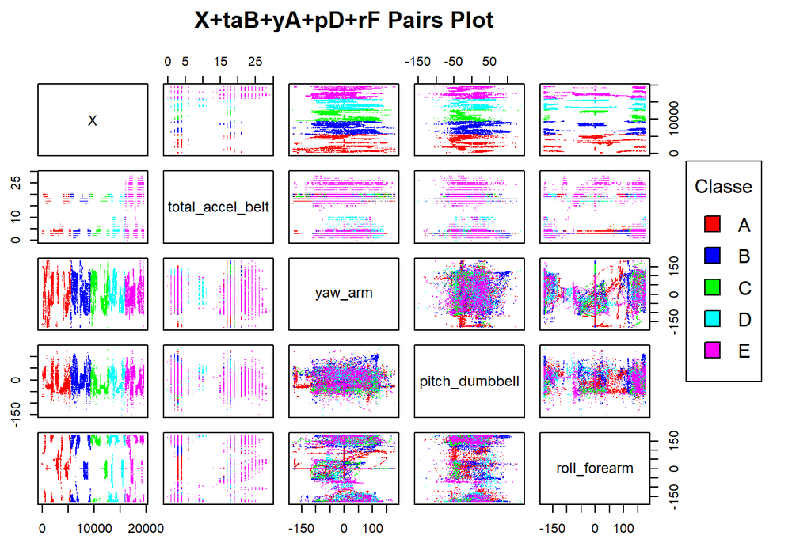

## Build a Tree Prediction Model

Remove the first five columns (metadata) which should not be part of the prediction model.  
Set up 10-fold cross-validation. Train the model using Bagged CART (method=“treebag”).

```r
#Do not include first five columns ('X', 'username', three timestamp columns)
pmlTraining1 <- select(pmlTraining,-X,-user_name,-raw_timestamp_part_1,-raw_timestamp_part_2,-cvtd_timestamp)
set.seed(11111)


tr_ctrl <- trainControl(method="cv",number = 10)
tbag_mdl <- train(classe~.,data=pmlTraining1,method="treebag", trControl=tr_ctrl)

# summarize results of the model after calculating prediction error in each case
print(tbag_mdl)
```

```
## Bagged CART
##
## 17662 samples
##    54 predictor
##     5 classes: 'A', 'B', 'C', 'D', 'E'
##
## No pre-processing
## Resampling: Cross-Validated (10 fold)
## Summary of sample sizes: 15895, 15896, 15897, 15894, 15896, 15895, ...
## Resampling results:
##
##   Accuracy   Kappa
##   0.9951874  0.9939129
```

The model has a predicted out-of-sample error rate of 1-0.9951874, or 0.0048126 (0.48%).

## Predict the pmlValidating Dataset

Let’s get an idea for whether the accuracy on the validation set is similar to what the 10-fold cross-validation estimated.

```r
cat("\n Bagged CART Prediction Accuracy: \n")
```

```
##
##  Bagged CART Prediction Accuracy:
```

```r
tbag_preds <- predict(tbag_mdl,pmlValidating)
mean(pmlValidating$classe == tbag_preds)
```

```
## [1] 0.9938776
```

```r
cat("\n Bagged CART  Confusion Matrix: \n")
```

```
##
##  Bagged CART  Confusion Matrix:
```

```r
confusionMatrix(pmlValidating$classe,tbag_preds)
```

```
## Confusion Matrix and Statistics
##
##           Reference
## Prediction   A   B   C   D   E
##          A 557   1   0   0   0
##          B   1 375   2   1   0
##          C   1   0 341   0   0
##          D   1   0   2 318   0
##          E   0   0   0   3 357
##
## Overall Statistics
##
##                Accuracy : 0.9939
##                  95% CI : (0.9893, 0.9968)
##     No Information Rate : 0.2857
##     P-Value [Acc > NIR] : < 2.2e-16
##
##                   Kappa : 0.9923
##
##  Mcnemar's Test P-Value : NA
##
## Statistics by Class:
##
##                      Class: A Class: B Class: C Class: D Class: E
## Sensitivity            0.9946   0.9973   0.9884   0.9876   1.0000
## Specificity            0.9993   0.9975   0.9994   0.9982   0.9981
## Pos Pred Value         0.9982   0.9894   0.9971   0.9907   0.9917
## Neg Pred Value         0.9979   0.9994   0.9975   0.9976   1.0000
## Prevalence             0.2857   0.1918   0.1760   0.1643   0.1821
## Detection Rate         0.2842   0.1913   0.1740   0.1622   0.1821
## Detection Prevalence   0.2847   0.1934   0.1745   0.1638   0.1837
## Balanced Accuracy      0.9970   0.9974   0.9939   0.9929   0.9991
```

On the data held out for validation, the error was 1-0.9938776 = 0.0061224 (0.61%). This appears to be a fairly accurate prediction model.

## Predict the pmlTesting Dataset

```r
#  pmlTesting dataset does not have a classe variable.
#  there is a problem_id column which presumably makes this a blind study.  :(
#  So no confusion matrices or accuracy numbers will be available.

# need to subset the training dataset and do validation there.

tbag_testpreds <- predict(tbag_mdl,pmlTesting)

for (i in 1:nrow(pmlTesting)) {

  cat("\n problem_id ",pmlTesting$problem_id[i]," | Predicted classe: ", as.character(tbag_testpreds[i]))

}
```

```
##
##  problem_id  1  | Predicted classe:  B
##  problem_id  2  | Predicted classe:  A
##  problem_id  3  | Predicted classe:  B
##  problem_id  4  | Predicted classe:  A
##  problem_id  5  | Predicted classe:  A
##  problem_id  6  | Predicted classe:  E
##  problem_id  7  | Predicted classe:  D
##  problem_id  8  | Predicted classe:  B
##  problem_id  9  | Predicted classe:  A
##  problem_id  10  | Predicted classe:  A
##  problem_id  11  | Predicted classe:  B
##  problem_id  12  | Predicted classe:  C
##  problem_id  13  | Predicted classe:  B
##  problem_id  14  | Predicted classe:  A
##  problem_id  15  | Predicted classe:  E
##  problem_id  16  | Predicted classe:  E
##  problem_id  17  | Predicted classe:  A
##  problem_id  18  | Predicted classe:  B
##  problem_id  19  | Predicted classe:  B
##  problem_id  20  | Predicted classe:  B
```